# Introduction

Session 2

Luis F. Gómez L.

luis.gomezl@unimilitar.edu.co

Distance Learning Faculty

26 January, 2026

# Please Read Me

- Check the message **Welcome greeting** published in Announcements forum.
- Dear student please edit your profile uploading a photo where your face is clearly visible.
- If you want to participate, please fill out the following survey: **Primer corte 30% > Learning Activities > Tu opinión sobre la economía colombiana**
- This presentation is based on (Cardenas, 2020, Chapter 1)
- **Purpose**
  - Identify the main characteristics of the Colombian economy, especially those that differentiate it from other economies

# Firms or enterprises

Table 1: ISIC adapted for Colombia (DANE, 2022, pp. 134–677)

| Section | Division | Description |
| --- | --- | --- |
| A | 01-03 | Agricultura, ganadería, caza, silvicultura y pesca |
| B | 05-09 | Explotación de minas y canteras |
| C | 10-33 | Industrias manufactureras |
| D | 35 | Suministro de electricidad, gas, vapor, y aire acondicionado |
| E | 36-39 | Distribución de agua; evacuación y tratamiento de aguas residuales, gestión de desechos y actividades de saneamiento ambiental |
| F | 41-43 | Construcción |
| G | 45-47 | Comercio al por mayor y al por menor; reparación de vehículos automotores y motocicletas |
| H | 49-53 | Transporte y almacenamiento |
| I | 55-56 | Alojamiento y servicios de comida |
| J | 58-63 | Información y comunicaciones |
| K | 64-66 | Actividades financieras y de seguros |

Table 2: ISIC adapted for Colombia (DANE, 2022, pp. 134–677)

| Section | Division | Description |
| --- | --- | --- |
| L | 68 | Actividades inmobiliarias |
| M | 69-75 | Actividades profesionales, científicas y técnicas |
| N | 77-82 | Actividades de servicios administrativos y de apoyo |
| O | 84 | Administración pública y defensa; planes de seguridad social de afiliación obligatoria |
| P | 85 | Educación |
| Q | 86-88 | Actividades de atención de la salud humana y de asistencia social |
| R | 90-93 | Actividades artísticas, de entretenimiento y recreación |
| S | 94-96 | Otras actividades de servicios |
| T | 97-98 | Actividades de los hogares en calidad de empleadores; actividades no diferenciadas de los hogares individuales como productores de bienes y servicios para uso propio |
| U | 99 | Actividades de organizaciones y entidades extraterritoriales |

- Some key definitions:
  - **Enterprise**: *“An economic unit that produces goods and services, made up of one or more establishments, which has the capacity in its own right to own assets, incur liabilities and carry out economic activities and transactions with other units.”* (DANE, 2024, p. 92)
  - **Establishment**: *“An economic unit with facilities defined by constructions that are permanently located in the same place, in which factors and resources are combined for the development of one or more economic activities.”* (DANE, 2024, p. 92)
- Some key definitions *in the context of manufacturing, assuming the unit of observation is the establishment and the data is reported yearly*:
  - **Aggregate value (Valor Agregado)**: Gross Production (Producción Bruta) - Intermediate Consumption (Consumo Intermedio) (DANE, 2024, p. 32)
  - **Gross Production (Producción Bruta)** (DANE, 2024, p. 28):
    - Value of all products, byproducts and work manufactured by the establishment in the year (+)
    - Value of electrical energy sold (+)
    - Value of subsidies accrued (causados) in the year (+)
    - Value of inventories of products in the process of manufacture at year end (+)
    - Value of products in the process of manufacture at the beginning of the year (-)
- Some key definitions *in the context of manufacturing, assuming the unit of observation is the establishment and the data is reported yearly*:
  - **Intermediate Consumption**: Value of non-durable goods and services used as inputs in the production process to produce other goods and services (Consumo Intermedio) (DANE, 2024, p. 29)
    - For a detailed list about the variables included when calculating intermediate consumption check out (DANE, 2024, pp. 29–31)

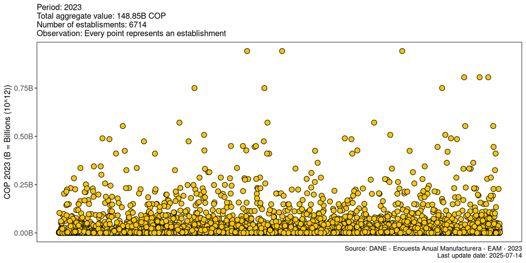

Figure 1: Distribution of aggregate value by establishment in the manufacturing Colombian sector

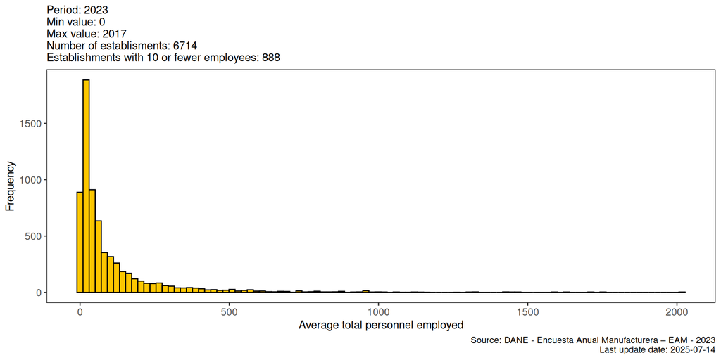

Figure 2: Distribution of average yearly total personnel employed in the manufacturing Colombian sector

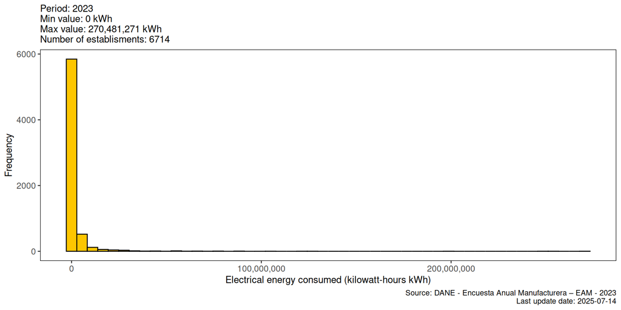

Figure 3: Distribution of electrical energy consumed in the manufacturing Colombian sector

# Natural environment

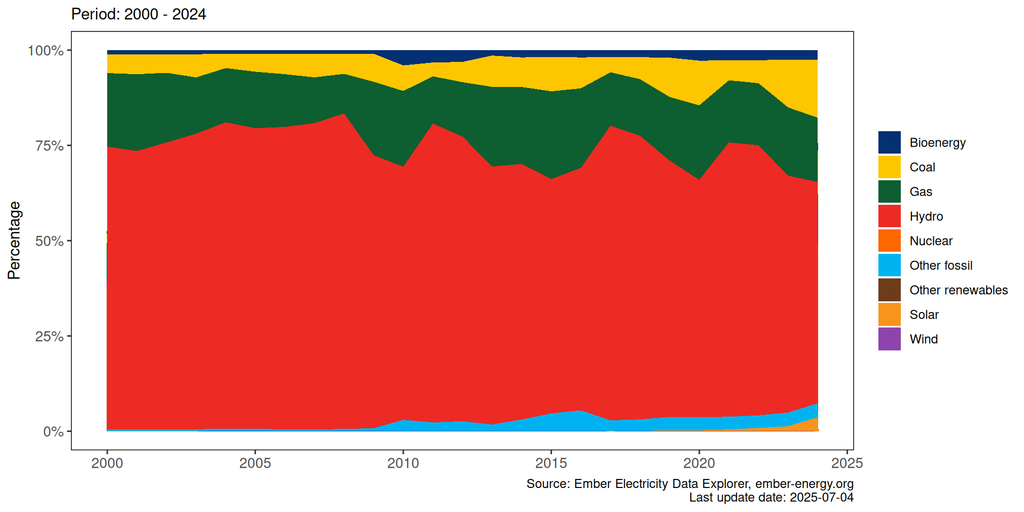

Figure 4: Percentage share of Colombia electricity generation by source

# Products

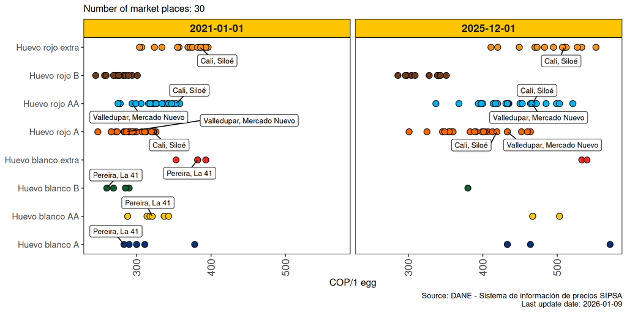

Figure 5: Egg mean wholesale prices in Colombian market places

# Flows and stocks

- **Stock**: a variable that is measured at a particular point in time
- **Flow**: a variable that is measured over a period of time
- Example *Declaración de renta Gustavo Francisco Petro Urrego Año Gravable 2023*:
  - https://www.funcionpublica.gov.co/fdci/consultaCiudadana
    - Tipo de persona: NATURAL
    - Primer nombre: Gustavo
    - Segundo nombre: Francisco
    - Primer apellido: Petro
    - Segundo apellido: Urrego

Table 3: Net worth (stock)

**Patrimonio (2023-12-31)**

| Total patrimonio bruto | $1,573,515,000 |
| --- | --- |
| Deudas | $280,563,000 |
| Total patrimonio líquido | $1,292,952,000 |

Table 4: Labor income (flow)

**Rentas de trabajo (2023-01-01 - 2023-12-31)**

| Ingresos brutos | $718,441,000 |
| --- | --- |
| Ingresos no constitutivos de renta | $13,920,000 |
| Renta líquida | $704,521,000 |

# Acknowledgments

- To my family that supports me
- To the taxpayers of Colombia and the [**UMNG students**](https://www.umng.edu.co/estudiante) who pay my salary
- To the [**Business Science**](https://www.business-science.io/) and [**R4DS Online Learning**](https://www.rfordatasci.com/) communities where I learn [**R**](https://www.r-project.org/about.html) and [**$\pi$-thon**](https://www.python.org/about/)
- To the [**R Core Team**](https://www.r-project.org/contributors.html), the creators of [**RStudio IDE**](https://posit.co/download/rstudio-desktop/), [**Positron**](https://positron.posit.co/), [**Quarto**](https://quarto.org/) and the authors and maintainers of the packages [**tidyverse**](https://CRAN.R-project.org/package=tidyverse), [**gt**](https://CRAN.R-project.org/package=gt), [**janitor**](https://CRAN.R-project.org/package=janitor), [**scales**](https://CRAN.R-project.org/package=scales), [**readxl**](https://CRAN.R-project.org/package=readxl), [**ggrepel**](https://CRAN.R-project.org/package=ggrepel) and [**tinytex**](https://CRAN.R-project.org/package=tinytex) for allowing me to access these tools without paying for a license

# References

Cardenas, M. (2020). *Introducción a la Economía Colombiana* (4th ed.). Alfaomega.

DANE. (2022). *Clasificación Industrial Internacional Uniforme de todas las actividades económicas Revisión 4 Adaptada para Colombia (2022)*. https://www.dane.gov.co/files/sen/nomenclatura/ciiu/CIIU_Rev_4_AC2022.pdf

DANE. (2024). *Metodología General Encuesta Anual Manufacturera - EAM*. https://microdatos.dane.gov.co/index.php/catalog/836/download/23670